# browsertime: live applink coldload, Chrome 74 vs GVE 68 vs Fenix 68 vs Fennec 64 on the Pixel 2 (and Moto G5, XXX)

### Comparison across sites

Especially for the faster sites – those that look like landing pages – Gecko is loading sites almost as quickly as is Chrome, but the time to navigation start makes Chrome a clear winner. In the visual below, the median page load time is wide and stacked on the bottom, and the median time to navigation start is thin and stacked on the top. Sites like web.de clearly show Gecko and Chrome loading the page similarly but Fenix suffering from the GeckoView startup time.

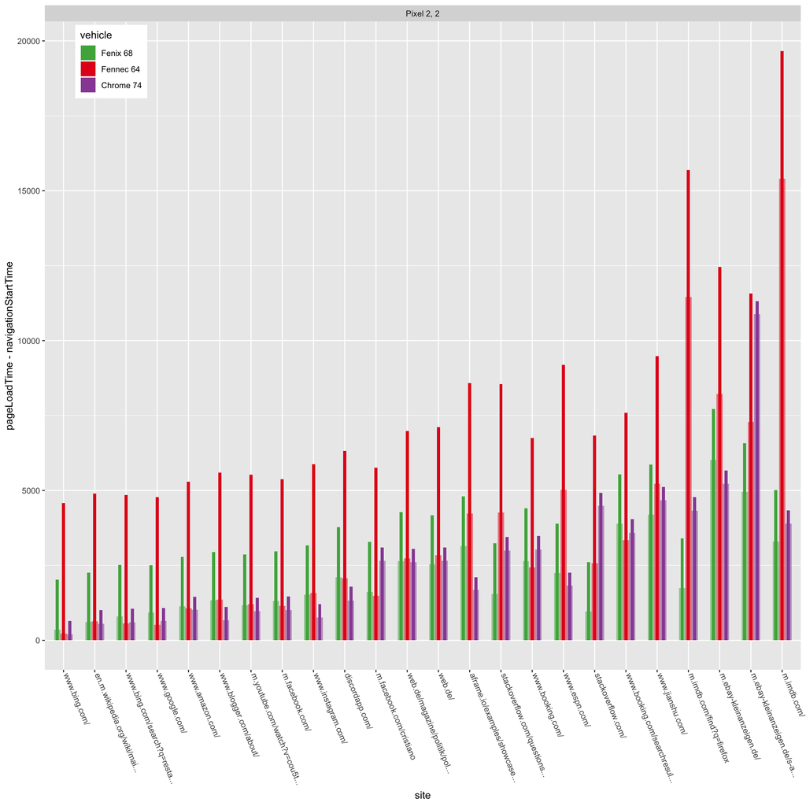

## Fenix 68 vs Fennec 64

Restricted to live sites.

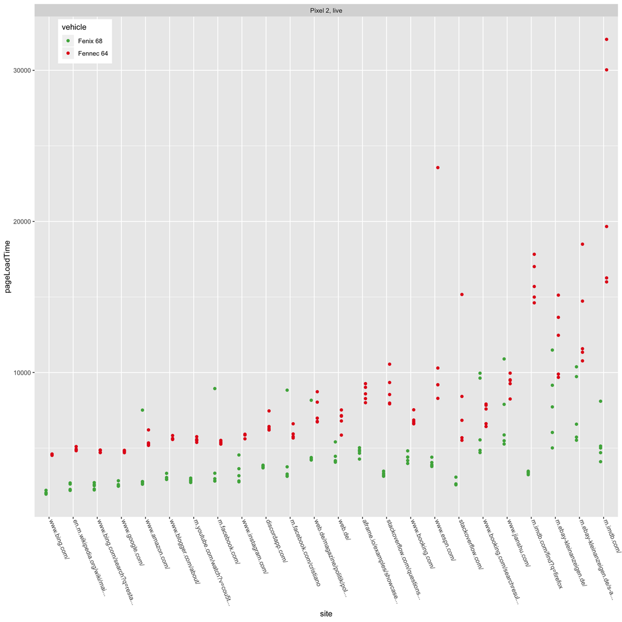

## Fenix 68 vs Chrome 74

Restricted to live sites.

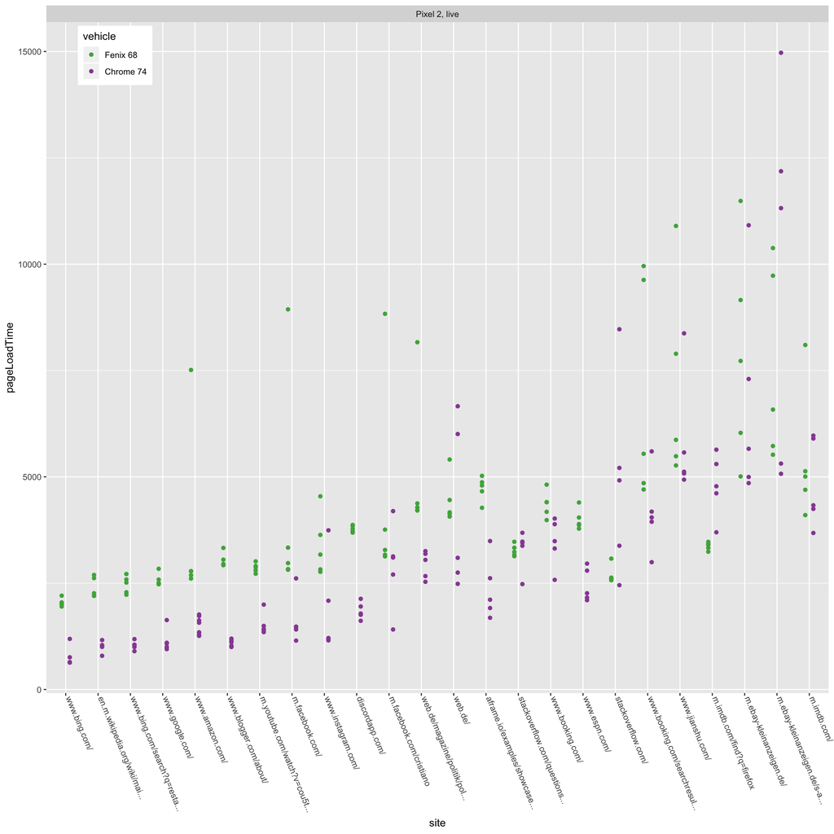

Here is the data in tabular form.

|  | run | device | site | Fenix 68 | Chrome 74 | ratio |
| --- | --- | --- | --- | --- | --- | --- |
| 1 | 2 | Pixel 2 | stackoverflow.com/ | 2694 | 4886 | 0.551371264838314 |
| 2 | 2 | Pixel 2 | m.imdb.com/find?q=firefox | 3372 | 4805 | 0.701768990634756 |
| 3 | 2 | Pixel 2 | m.ebay-kleinanzeigen.de/s-a... | 7587 | 9771 | 0.776481424623887 |
| 4 | 2 | Pixel 2 | stackoverflow.com/questions... | 3267 | 3294 | 0.991803278688525 |
| 5 | 2 | Pixel 2 | web.de/ | 4445 | 4199 | 1.05858537747083 |
| 6 | 2 | Pixel 2 | m.imdb.com/ | 5407 | 4826 | 1.12038955656859 |
| 7 | 2 | Pixel 2 | m.ebay-kleinanzeigen.de/ | 7883 | 6745 | 1.16871756856931 |
| 8 | 2 | Pixel 2 | www.jianshu.com/ | 7083 | 5816 | 1.21784731774415 |
| 9 | 2 | Pixel 2 | www.booking.com/ | 4357 | 3458 | 1.25997686524002 |
| 10 | 2 | Pixel 2 | m.facebook.com/cristiano | 4434 | 2908 | 1.52475928473177 |

[output cut: 14 more lines]

## Conclusions

1. **A Quantum Flow-like startup performance effort is needed.** If Chrome can start navigating in less than 0.5s, so can we!
2. Since the particular site makes almost no difference to the `navigationStartTime`, meaning that a few (or even one) representative site(s) is sufficient to measure and track regressions in the applink load time. That will reduce the automation cost for regression testing.

## Results

### Raw data

The data collected for the following tests is available:

[output not shown]

### Processed data

The data from the test runs above can be found in the following CSV file. The columns of the CSV are as follows:

[output not shown]

## Inter-vehicle reliability

### Network weather and live site differences

No record and replay proxy was used to minimize the impact of network weather.

Some of the sites serve dynamic content and/or advertisements. This means that between individual tests, the underlying network archives may have changed significantly.

### Gecko profile conditioning

It is well known that the Gecko profile significantly impacts the performance of the Gecko engine: preferences, certificate databases, and the network cache itself can have major impacts on measurements.

To minimize volatility, for each GeckoView-based vehicle configuration, a Gecko profile was conditioned as follows:

1. A profile template (with `cert9.db` and `key4.db` containing the custom CA certificate used by proxies) was produced.
2. This profile template was copied to the target device, and the vehicle was started from a cleared state with this profile.
3. The single page `https://example.com` was visited.
4. The vehicle was left idle for 2 minutes.
5. The vehicle was force-stopped and the conditioned profile retrieved from the device.

This conditioned profile was then copied to the device at the beginning of every test run: that is, every applink cold pageload started with exactly the same Gecko profile.

The code that implements this profile conditioning can be found [here](https://hg.mozilla.org/users/nalexander_mozilla.com/gecko/file/face4e993f959724fe86b302987091666e3193cd/testing/perftest/perftest/condition.py).

## Versions

### Device versions

The output of `adb shell getprop` for each device is available:

| device |
| --- |
| Pixel 2 |
| Moto G5 |

### Software versions

| package | version (* denotes modified) | link |
| --- | --- | --- |
| browsertime | 4.7.0 (*) | https://github.com/ncalexan/browsertime/tarball/4f8738e2225b3298556308c0d8c916d3b22e9741 |
| chromedriver | 2.46 (*) | https://chromedriver.storage.googleapis.com/index.html?path=2.46/ |
| geckodriver | 0.40.0 (*) | https://hg.mozilla.org/users/nalexander_mozilla.com/gecko/rev/e7f1d26dec97a4a26c61b8e18dfe769d4c11e096 |
| Fenix | 1.0.1917 | https://queue.taskcluster.net/v1/task/TujyjjJqSoqeSVykLTjdmA/artifacts/public%2Ftarget.apk |
| geckoview_example | N/A | https://queue.taskcluster.net/v1/task/EbHvScwDQBWnoYHJRwZphQ/artifacts/public%2Fbuild%2Fgeckoview_example.apk |
| Fennec | 64.0.2 | http://archive.mozilla.org/pub/mobile/releases/64.0.2/android-api-16/multi/fennec-64.0.2.multi.android-arm.apk |
| Chrome | 74.0.3729.112 | N/A |